# BTracT

Banana Tracking Tool

BTracT is a system of integrated tools through API which consists of [Musabase](https://musabase.org) and [Open data kit](https://opendatakit.org/)

In order to use BTracT, you need to

1. Have an **android** mobile phone or tablet. Install,
   - [ODK collect](https://play.google.com/store/apps/details?id=org.odk.collect.android&hl=en)
   - [ODK Sensors Framework](https://play.google.com/store/apps/details?id=org.opendatakit.sensors&hl=en)
   - ODK printer driver (contact admin)
2. Mobile printer (zebra zq520)
3. User **accounts** in
   - Musabase [test site](https://musabase-test.sgn.cornell.edu/breeders/crosses/) or [live site](https://musabase.org) and
   - [ONA](https://ona.io/home/) (ODK aggregate server)
4. Generate a crossing plan through Musabase
5. Configure mobile phone with user accounts
6. Collect data using mobile devices

# 1.0 Crossing plan

Crossing plan is generated with permissions through musabase.org

To create a crossing plan, go to **manage menu** >> select **crosses**

[figure not shown]

Click on **Add Cross Wishlist** (see highlight in the figure below)

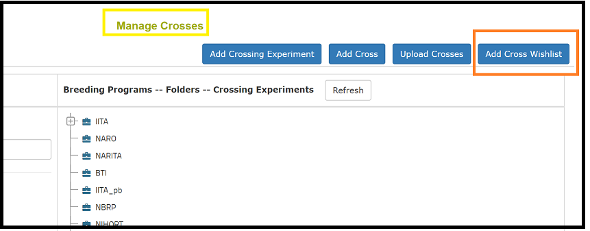

### 1.1 Using specific field trial names

1. Select your tool, specific to your site eg. BTracTTest in the Musabase test site

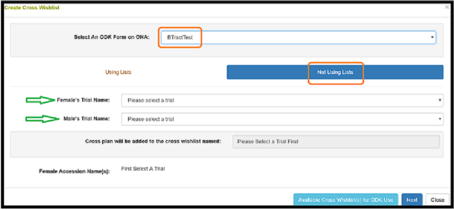

2. Select the **Female** and **Male** trials. Select the specific accessions and assign priority. Click **Next**

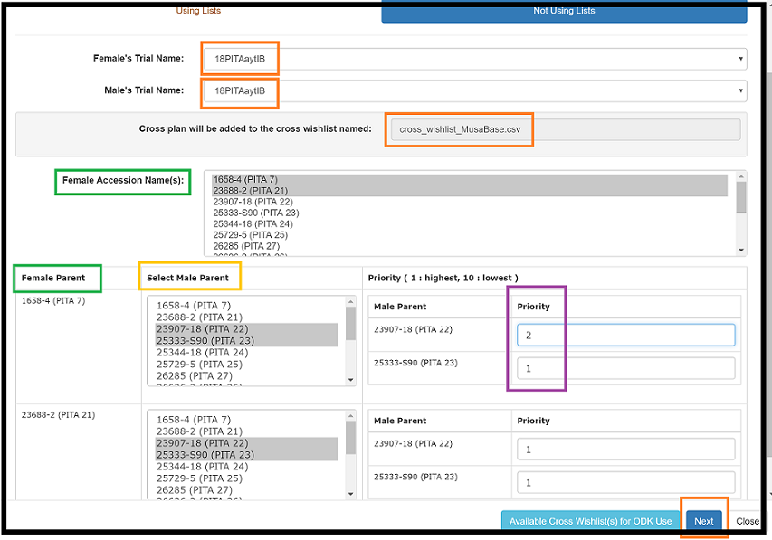

### 1.2 Using lists

1. First create your **female** and **male** lists

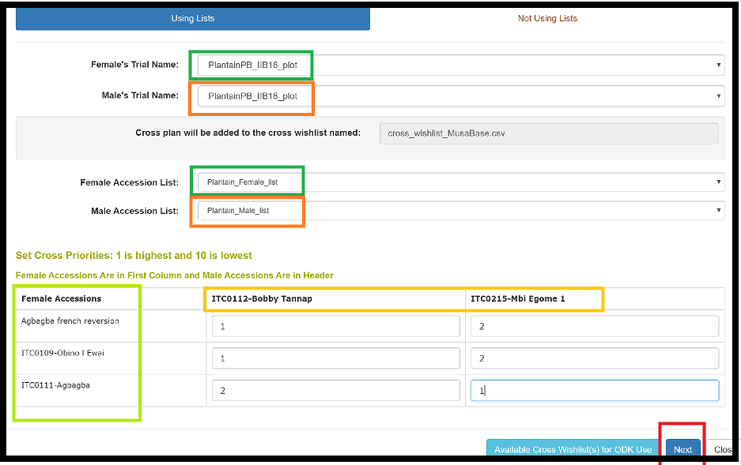

**Next**

2. Select **all female plots** or **specific plots** in a block/field.

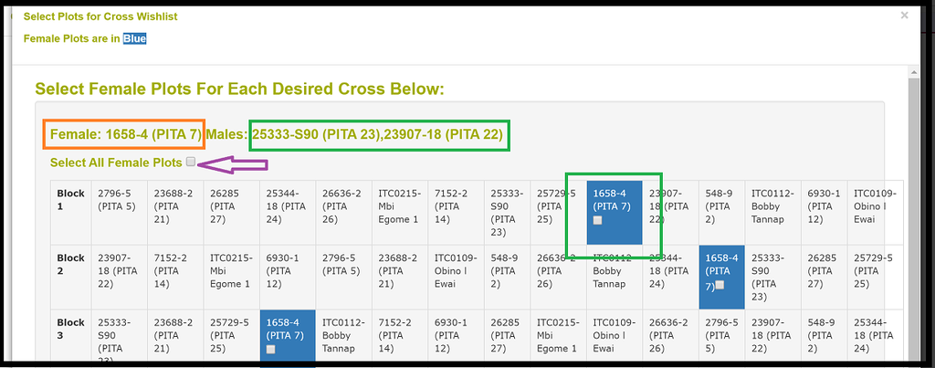

# 2.0 Configure ODK Collect

# 3.0 Data collection

BTracT get started

BTracT data collection tool is divided into three main sections

1. Field Activities
   - Flowering
   - First pollination
   - Repeat pollination
   - Bunch harvesting
   - Seed extraction
   - Plant status
2. Laboratory
   - Embryo culture
   - Embryo germination
   - Tissue culture
   - Rooting
   - Contamination
3. Nursery
   - Potting
   - Hardening
   - Open field